# Serie transporte viajero Urbano en España

Ahora representemos la serie con la tendencia y la serie ajustada estacionalmente

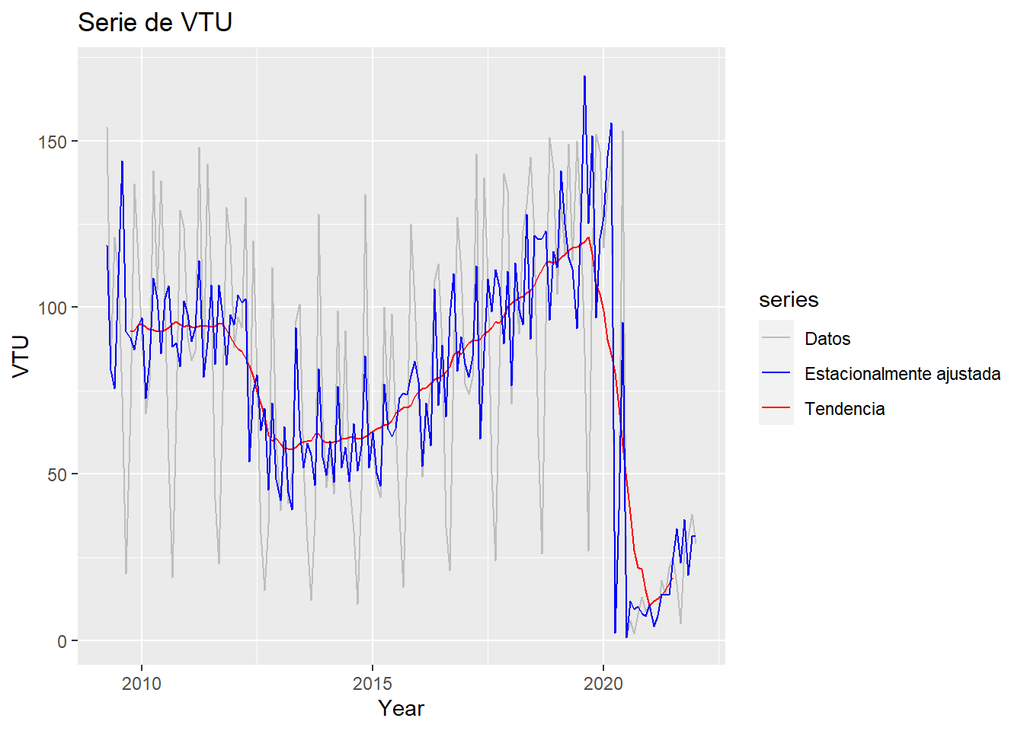

```r
autoplot(turbano, series="Datos") +
autolayer(trendcycle(viajerosu), series="Tendencia")+
autolayer(seasadj(viajerosu), series="Estacionalmente ajustada")+
xlab("Year") + ylab("VTU") +
ggtitle("Serie de VTU") +
scale_colour_manual(values=c("gray","blue","red"), breaks=c("Datos","Estacionalmente ajustada","Tendencia"))
```

Ahora realicemos el análisis de la serie de cada año.

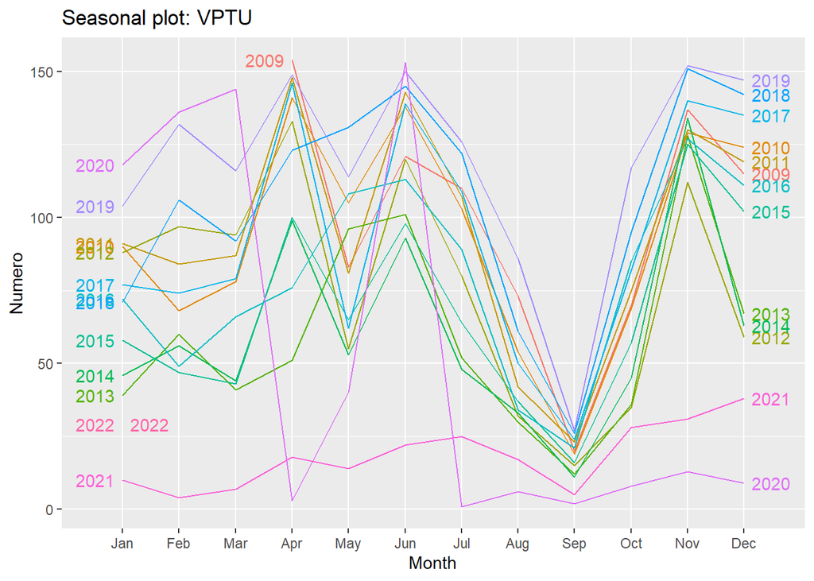

```r
ggseasonplot(turbano, year.labels=TRUE, year.labels.left=TRUE) +
ylab("Numero") +
ggtitle("Seasonal plot: VPTU")
```

**Ejercicio 3.** Para comprobar la eficacia de los métodos de predicción que vamos a hacer en los siguientes apartados reservamos los últimos datos observados (un periodo en las series estacionales o aproximadamente 10 observaciones) para comparar con las predicciones realizadas por cada uno de los métodos. Luego ajustamos los modelos sobre la serie sin esos últimos datos en los siguientes apartados.

Reservaremos los datos de entrenamiento aproximadamente hasta Febrero del 2020, para comparar las predicciones.

```r
vtu_train<- window(turbano, end=c(2020,2))
```

**Ejercicio 4. (2)** Encontrar el modelo de suavizado exponencial más adecuado. Para dicho modelo, representar gráficamente la serie observada y la suavizada con las predicciones para un periodo que se considere adecuado.

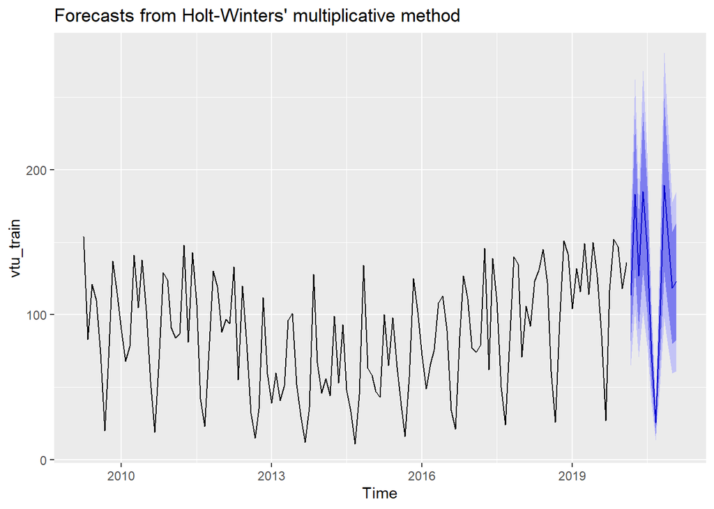

```r
vtu_sh <- hw(vtu_train,seasonal="multiplicative", h=12,level = c(80, 95))
autoplot(vtu_sh)
```

```r
print(vtu_sh)
```

```
##          Point Forecast     Lo 80     Hi 80     Lo 95     Hi 95
## Mar 2020      113.37156  81.71229 145.03084  64.95288 161.79025
## Apr 2020      183.14458 131.09069 235.19848 103.53502 262.75415
## May 2020      126.90409  90.21398 163.59419  70.79141 183.01676
## Jun 2020      185.17103 130.74227 239.59979 101.92942 268.41264
## Jul 2020      145.43125 101.99248 188.87003  78.99738 211.86512
## Aug 2020       73.12362  50.93975  95.30749  39.19631 107.05092
## Sep 2020       25.55118  17.68149  33.42088  13.51552  37.58685
## Oct 2020       99.52239  68.41570 130.62908  51.94882 147.09596
## Nov 2020      189.26972 129.25904 249.28041  97.49131 281.04814
## Dec 2020      154.99468 105.16174 204.82761  78.78178 231.20757
## Jan 2021      118.59307  79.94235 157.24379  59.48190 177.70425
## Feb 2021      123.14672  82.47675 163.81670  60.94736 185.34608
```

Mostramos las predicciones anteriores con un intervalo de confianza del 80% al 95%.

Los parámetros del modelo ajustados son:

```r
knitr::kable(vtu_sh$model$par, format = 'pipe',digits=3, caption='Estimadores de los parámetros')
```

Estimadores de los parámetros

|  | x |
| --- | --- |
| alpha | 0.185 |
| beta | 0.000 |
| gamma | 0.000 |
| l | 97.562 |
| b | 0.059 |
| s0 | 0.887 |
| s1 | 0.958 |
| s2 | 0.923 |
| s3 | 1.207 |
| s4 | 1.474 |
| s5 | 0.776 |
| s6 | 0.199 |
| s7 | 0.571 |
| s8 | 1.136 |
| s9 | 1.446 |
| s10 | 0.992 |

**Ejercicio 5. (3)** Representar la serie y los correlogramas. Decidir que modelo puede ser ajustado. Ajustar el modelo adecuado comprobando que sus residuales están incorrelados. (Sintaxis, tablas de los parámetros estimados y gráficos)

Calculamos las autocorrelaciones simples hasta el retardo 48

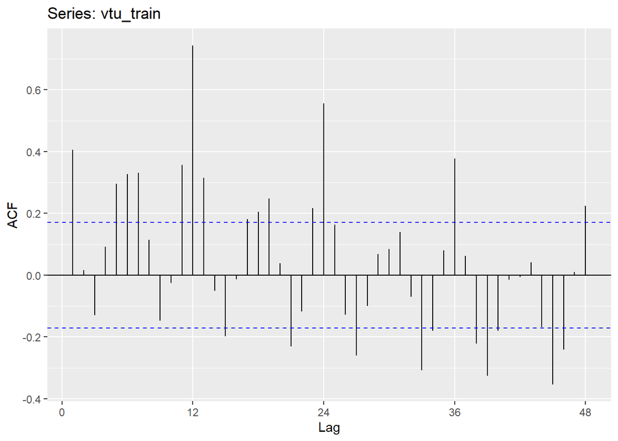

```r
ggAcf(vtu_train, lag=48)
```

Coeficiente de correlación parcial,

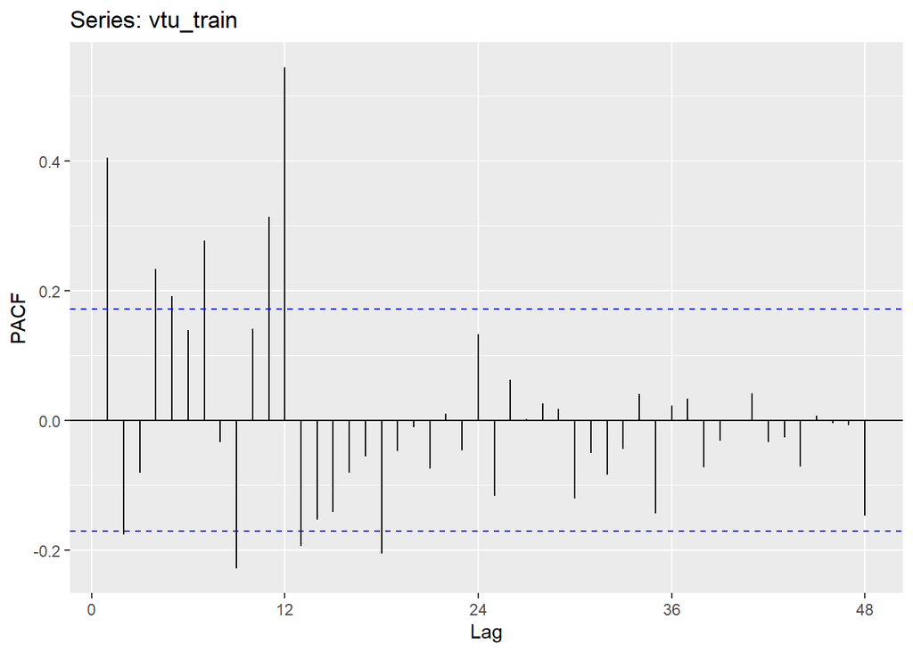

```r
#Calculamos las autocorrelaciones parciales hasta el retardo 48
ggPacf(vtu_train, lag=48)
```

Notemos que el comportamiento es normal por ser una serie no estacionaria pero si estacional, además, la dependencia entre el instate x_t y x_t-12 es muy fuerte.

Realicemos las diferenciaciones de orden adecuado y veamos nuevamente las autocorrelaciones

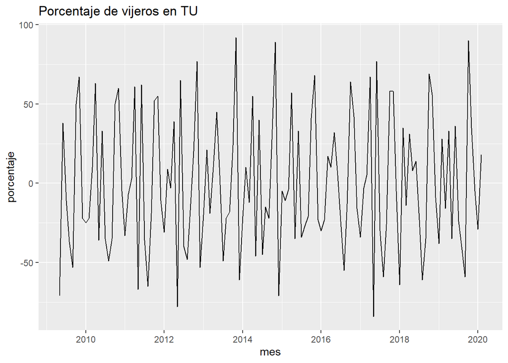

```r
autoplot(diff(vtu_train))+ ggtitle("Porcentaje de vijeros en TU") +xlab("mes") + ylab("porcentaje")
```

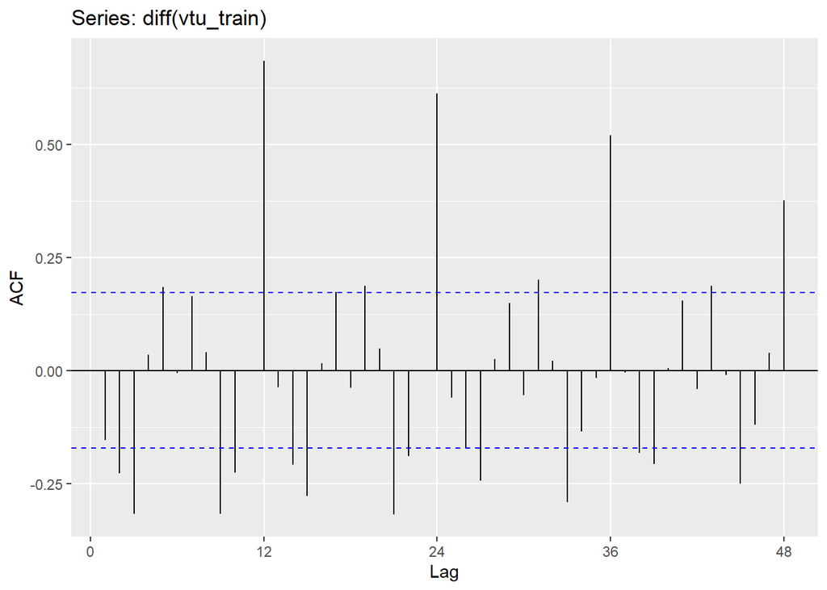

```r
ggAcf(diff(vtu_train), lag=48)
```

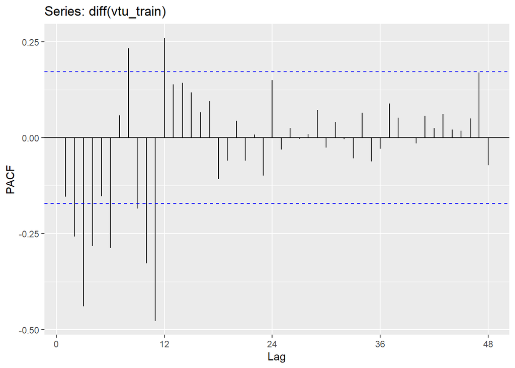

```r
ggPacf(diff(vtu_train), lag=48)
```

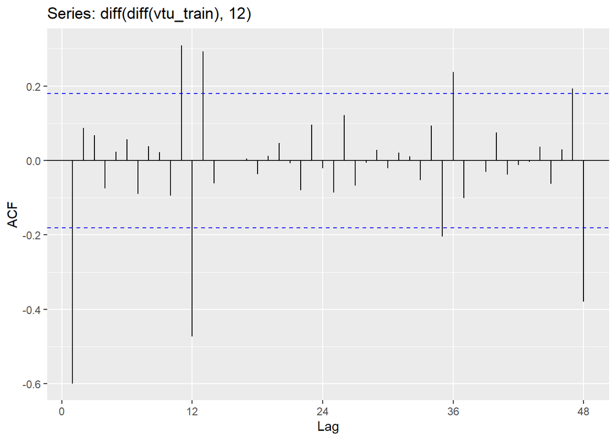

```r
ggAcf(diff(diff(vtu_train),12), lag=48)
```

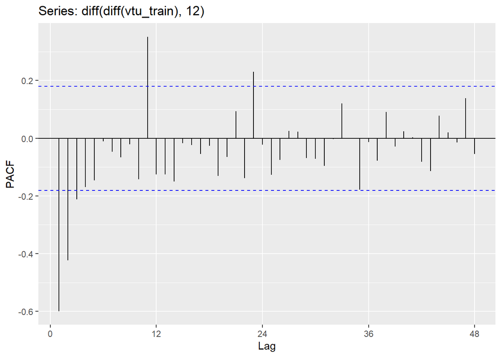

```r
ggPacf(diff(diff(vtu_train),12), lag=48)
```